# Dupi Olfactory Gamma Analysis

Inventory · behavioral recovery · macBP gamma selection · per-breath gamma characterization

plotsForBruce_2 pipeline

2026-09-08

# 1 Overview

This report analyzes gamma-band (25–58 Hz) activity on intracranial macro-bipolar (macBP) channels in the **Dupi** intervention cohort, locked to breaths and sniffs, and asks which gamma measures are **stable across controls** while **separating controls from Dupi**, **separating responders from non-responders**, or **tracking olfactory recovery** across sessions.

**Cohorts.** Dupi = intervention, up to three sessions per participant (S1/S2/S3). **Control = OBEControl (OBE)**. The EEGbreathing (EEG) cohort is **excluded** — those recordings carry no nasal/depth electrode on which to measure gamma.

**Design decisions:**

- Best macBP channel selected per recording by **peak power after FOOOF spectral flattening in 25–58 Hz** (highest gamma).
- Superlet time-frequency power (fractional adaptive, base cycles 3, order 3–30), validated to machine precision against the reference `faslt`.
- Ridge tracked with the **Frequency_ridge_tracking** forward–backward algorithm (ported to MATLAB), on the per-breath within-frequency z-scored power (`myChanZscore`, no baseline).
- **Both** whole-window z and a pre-inhale baseline z are computed, so burst/peak results can be checked against the choice of normalization window.
- **Per-breath FOOOF** (aperiodic exponent/offset + periodic gamma peak presence) so a “gamma” claim is not confused with a broadband 1/f shift.
- Per-breath **breathing/airflow covariates** (inhale volume, duration, peak flow) and `goodBreath` QC are carried, to address the sniff-airflow confound.
- Group statistics **aggregate to session level first** (each session = one observation), avoiding trial-count bias.

# 2 Inventory

```
## Analysis set: Dupi + OBE (EEG excluded). Finals on disk by task:
```

On-disk finals (Dupi vs OBE) per task

| task | Dupi | OBE |
| --- | --- | --- |
| O15 | 28 | 11 |
| breathingTask | 29 | 7 |
| cueTask | 30 | 11 |
| threshTask | 30 | 5 |

## 2.1 Dupi participant × session grid

Dupi participants: tasks present per session (B=breathing C=cue T=thresh O=O15)

| participant | S1 | S2 | S3 | nSessions |
| --- | --- | --- | --- | --- |
| AB | BCOT | BCOT | BCOT | 3 |
| BS | BCOT | COT | NA | 2 |
| DB | BCOT | BCOT | NA | 2 |
| DL | BCOT | NA | NA | 1 |
| GH | BCOT | BCOT | BCT | 3 |
| JA | BCOT | BCT | NA | 2 |
| JH | BCOT | BCOT | BCOT | 3 |
| JL | BCOT | BCOT | NA | 2 |
| JN | NA | BCOT | BCOT | 2 |
| KS | BCOT | BCOT | BCOT | 3 |
| PC | BCOT | BCOT | NA | 2 |
| PD | BCOT | BCOT | NA | 2 |
| TB | BCOT | BCOT | BCOT | 3 |

## 2.2 Missing / unprocessed (both directions)

```
## **Sheet-listed sessions missing a preproc final:**
```

In the tracking sheet but no final on disk

| task | sessID | cohort | group | participant | sessNum |
| --- | --- | --- | --- | --- | --- |
| O15 | 260504_Dupi_NMH_JA_2 | Dupi | DupiS2 | JA | 2 |

```
##
##
## **Session folders on disk NOT in the analysis set** (raw folders with no preproc finals, or not marked raw-extracted):
```

On disk, absent from the sheet-driven analysis set

| cohort | sessID | inSheet | hasPreProcDir | finalsOnDisk | nFinals |
| --- | --- | --- | --- | --- | --- |
| Dupi | 250505_Dupi_NMH_AC_1 | FALSE | FALSE | NA | 0 |
| Dupi | 250505_Dupi_NMH_AC_2 | FALSE | FALSE | NA | 0 |
| Dupi | 250505_Dupi_NMH_AC_3 | FALSE | FALSE | NA | 0 |
| Dupi | 251013_Dupi_NMH_JN_1 | FALSE | FALSE | NA | 0 |
| Dupi | 251030_Dupi_NMH_DB_3 | FALSE | FALSE | NA | 0 |
| Dupi | 251110_Dupi_NMH_PC_3 | FALSE | FALSE | NA | 0 |
| Dupi | 251120_Dupi_NMH_JL_3 | FALSE | FALSE | NA | 0 |
| OBE | 240822_OBE_NMH_FM | FALSE | FALSE | NA | 0 |
| OBE | 241010_OBE_NMH_SJ | FALSE | FALSE | NA | 0 |
| OBE | 250217_OBE_NMH_AE | FALSE | FALSE | NA | 0 |
| OBE | 250217_OBE_NMH_AV | FALSE | FALSE | NA | 0 |
| OBE | 250225_OBE_NMH_AS | FALSE | FALSE | NA | 0 |
| OBE | 250225_OBE_NMH_AS_5 | FALSE | FALSE | NA | 0 |
| OBE | 250306_OBE_NMH_AS_newPt | FALSE | FALSE | NA | 0 |
| OBE | 250821_OBE_NWU_JG_1 | FALSE | FALSE | NA | 0 |
| OBE | 250825_OBE_NWU_HT | FALSE | FALSE | NA | 0 |
| OBE | 251208_OBE_NWU_KA_1 | FALSE | FALSE | NA | 0 |
| OBE | 251218_OBE_NWU_SM_1 | FALSE | FALSE | NA | 0 |
| OBE | 260105_OBE_NWU_AM_1 | FALSE | FALSE | NA | 0 |
| OBE | 260112_OBE_NWU_RM_1 | FALSE | FALSE | NA | 0 |
| OBE | 260122_OBE_NWU_DC_1 | FALSE | FALSE | NA | 0 |
| OBE | 260122_OBE_NWU_RA_1 | FALSE | FALSE | NA | 0 |
| OBE | 260420_OBE_NWU_SA_1 | FALSE | FALSE | NA | 0 |
| OBE | 260514_OBE_NWU_CS_1 | FALSE | FALSE | NA | 0 |
| OBE | 260521_OBE_NWU_RA_1 | FALSE | FALSE | NA | 0 |
| OBE | 260528_OBE_NWU_DM_1 | FALSE | FALSE | NA | 0 |
| OBE | 260625_OBE_NWU_CC_1 | FALSE | FALSE | NA | 0 |
| OBE | 260723_OBE_NWU_ES_1 | FALSE | FALSE | NA | 0 |
| OBE | 260817_OBE_NWU_CC_1 | FALSE | FALSE | NA | 0 |
| OBE | 260820_OBE_NWU_DW_1 | FALSE | FALSE | NA | 0 |
| OBE | 260820_OBE_NWU_RA_1 | FALSE | FALSE | NA | 0 |
| OBE | 260824_OBE_NWU_EZ_1 | FALSE | FALSE | NA | 0 |
| OBE | 260824_OBE_NWU_ZF_2 | FALSE | FALSE | NA | 0 |
| OBE | 260827_OBE_NWU_RX_2 | FALSE | FALSE | NA | 0 |
| OBE | 260831_OBE_NWU_CS_2 | FALSE | FALSE | NA | 0 |

## 2.3 Controls (OBE)

OBE control recordings (tasks present)

| sessID | participant | tasks | nTask |
| --- | --- | --- | --- |
| 230611_OBE_NMH_AZ | AZ | C | 1 |
| 240923_OBE_NMH_HRM | HRM | C | 1 |
| 241017_OBE_NMH_AS | AS | C | 1 |
| 250225_OBE_NWU_AS_4 | AS | O | 1 |
| 250310_OBE_NMH_FS | FS | C | 1 |
| 250313_OBE_NMH_CS | CS | C | 1 |
| 250904_OBE_NWU_TI_1 | TI | BO | 2 |
| 250908_OBE_NWU_AS | AS | BO | 2 |
| 251006_OBE_NWU_RY_1 | RY | O | 1 |
| 251009_OBE_NWU_CP_1 | CP | BO | 2 |
| 251208_OBE_NWU_SP_1 | SP | O | 1 |
| 260105_OBE_NWU_ZF_1 | ZF | O | 1 |
| 260326_OBE_NWU_AD_1 | AD | B | 1 |
| 260326_OBE_NWU_AD_2 | AD | BCO | 3 |
| 260514_OBE_NWU_BW_1 | BW | BCOT | 4 |
| 260608_OBE_NWU_RX_1 | RX | BCOT | 4 |
| 260622_OBE_NWU_RC_1 | RC | C | 1 |
| 260625_OBE_NWU_HM_2 | HM | T | 1 |
| 260702_OBE_NWU_SP_2 | SP | COT | 3 |
| 260720_OBE_NWU_KA_2 | KA | CT | 2 |

# 3 Behavioral olfactory performance

# 4 Composite Olfaction Index & responder split

The **Olfaction Index** is the mean of three normalized sub-scores (`O15_acc`, `thresh_low_cal/400`, `cue_d/3.5`). Dupi participants are split by **sustained recovery**: a **responder** ends at their final recorded session with a composite ≥ 0.40 (≈⅔ of the control mean, 0.64) **and** above their session-1 value; otherwise **non-responder**; a single-session participant is unclassified. This yields **4 responders (JH, AB, BS, PD), 8 non-responders, 1 unclassified (DL)** — correctly labelling the four participants who fell back at session 3 (GH, TB, KS, JN) as non-responders.

| participant | nSess | firstSess | lastSess | composite_S1 | composite_final | delta | class |
| --- | --- | --- | --- | --- | --- | --- | --- |
| JA | 2 | 1 | 2 | 0.4559237 | 0.3412058 | -0.1147179 | non-responder |
| PC | 2 | 1 | 2 | 0.4475183 | 0.2803149 | -0.1672034 | non-responder |
| GH | 3 | 1 | 3 | 0.0967874 | 0.1515851 | 0.0547977 | non-responder |
| DB | 2 | 1 | 2 | -0.0489492 | 0.1360609 | 0.1850101 | non-responder |
| TB | 3 | 1 | 3 | -0.1037268 | 0.0563964 | 0.1601232 | non-responder |
| JL | 2 | 1 | 2 | -0.0749739 | -0.0094785 | 0.0654954 | non-responder |
| KS | 3 | 1 | 3 | 0.1965322 | -0.0730248 | -0.2695570 | non-responder |
| JN | 2 | 2 | 3 | 0.2407440 | -0.1043481 | -0.3450921 | non-responder |
| JH | 3 | 1 | 3 | 0.0370648 | 0.8497849 | 0.8127202 | responder |
| AB | 3 | 1 | 3 | -0.0816880 | 0.6936784 | 0.7753664 | responder |
| BS | 2 | 1 | 2 | 0.0630853 | 0.6190203 | 0.5559350 | responder |
| PD | 2 | 1 | 2 | 0.2263226 | 0.4213628 | 0.1950402 | responder |
| DL | 1 | 1 | 1 | -0.1160737 | -0.1160737 | 0.0000000 | unclassified (single session) |

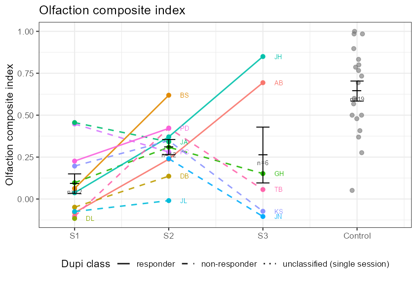

# 5 macBP gamma channel selection

For each recording, the **peak flattened power in 25–58 Hz (dB over the FOOOF aperiodic fit)** is shown for every macBP channel; the **maximum per recording is bold** (the selected channel). We also report whether the selected channel had a **FOOOF-detectable gamma peak**, and how many non-selected channels did.

Peak flattened power (dB) in 25–58 Hz per macBP channel; bold = selected (max).

| sessID | task | cohort | macBP1 | macBP2 | macBP3 | macBP4 | macBP5 | bestLabel | bestGammaDetected | nNonMaxDetected | nMacBP |
| --- | --- | --- | --- | --- | --- | --- | --- | --- | --- | --- | --- |
| 251002_Dupi_NMH_AB_1 | O15 | Dupi | 11.27 | 8.67 | 11.49 | 15.54 | 16.76 | macBP5 | 1 | 3 | 5 |
| 251002_Dupi_NMH_AB_1 | breathingTask | Dupi | 3.40 | 8.89 | 2.77 | 2.48 | 0.93 | macBP2 | 1 | 1 | 5 |
| 251002_Dupi_NMH_AB_1 | cueTask | Dupi | 3.19 | 6.61 | 3.11 | 0.73 | 1.42 | macBP2 | 0 | 1 | 5 |
| 251002_Dupi_NMH_AB_1 | threshTask | Dupi | 12.34 | 5.77 | 8.91 | 12.85 | 17.03 | macBP5 | 1 | 2 | 5 |
| 251002_Dupi_NMH_AB_2 | O15 | Dupi | 10.69 | 4.90 |  |  |  | macBP1 | 1 | 1 | 2 |
| 251002_Dupi_NMH_AB_2 | breathingTask | Dupi | 11.62 | 5.85 | 1.39 |  |  | macBP1 | 1 | 1 | 3 |
| 251002_Dupi_NMH_AB_2 | cueTask | Dupi | 11.11 | 13.19 |  |  |  | macBP2 | 1 | 1 | 2 |
| 251002_Dupi_NMH_AB_2 | threshTask | Dupi | 9.22 | 8.11 |  |  |  | macBP1 | 1 | 1 | 2 |
| 251002_Dupi_NMH_AB_3 | O15 | Dupi | 3.87 | 7.67 | 1.69 |  |  | macBP2 | 1 | 0 | 3 |
| 251002_Dupi_NMH_AB_3 | breathingTask | Dupi | 7.68 | 11.05 | 4.85 | 2.40 |  | macBP2 | 1 | 3 | 4 |
| 251002_Dupi_NMH_AB_3 | cueTask | Dupi | 9.38 |  |  |  |  | macBP1 | 1 | 0 | 1 |
| 251002_Dupi_NMH_AB_3 | threshTask | Dupi | 9.00 | 9.76 | 4.06 | 3.39 |  | macBP2 | 1 | 1 | 4 |
| 260406_Dupi_NMH_BS_1 | O15 | Dupi | 0.45 | 1.74 | 0.96 | 3.86 | 3.66 | macBP4 | 0 | 0 | 5 |
| 260406_Dupi_NMH_BS_1 | breathingTask | Dupi | 0.68 | 1.66 | 1.38 | 1.51 | 2.29 | macBP5 | 0 | 0 | 5 |
| 260406_Dupi_NMH_BS_1 | cueTask | Dupi | 3.82 | 1.29 | 1.12 | 2.97 | 4.08 | macBP5 | 0 | 0 | 5 |
| 260406_Dupi_NMH_BS_1 | threshTask | Dupi | 3.44 | 1.32 | 0.95 | 2.82 | 3.84 | macBP5 | 0 | 0 | 5 |
| 260406_Dupi_NMH_BS_2 | O15 | Dupi | 0.50 | 2.21 | 4.40 | 1.63 | 2.24 | macBP3 | 0 | 0 | 5 |
| 260406_Dupi_NMH_BS_2 | cueTask | Dupi | 0.68 | 1.47 | 2.21 | 3.13 |  | macBP4 | 0 | 0 | 4 |
| 260406_Dupi_NMH_BS_2 | threshTask | Dupi | 1.42 | 2.54 | 3.11 |  |  | macBP3 | 0 | 0 | 3 |
| 251030_Dupi_NMH_DB_1 | O15 | Dupi | 4.54 | 6.42 | 7.18 | 4.33 | 1.52 | macBP3 | 0 | 3 | 5 |
| 251030_Dupi_NMH_DB_1 | breathingTask | Dupi | 8.03 | 8.72 | 8.42 | 6.60 | 3.97 | macBP2 | 0 | 2 | 5 |
| 251030_Dupi_NMH_DB_1 | cueTask | Dupi | 7.75 | 8.84 | 8.00 | 4.12 | 4.03 | macBP2 | 0 | 1 | 5 |
| 251030_Dupi_NMH_DB_1 | threshTask | Dupi | 7.82 | 8.68 | 7.67 | 4.69 | 5.27 | macBP2 | 0 | 1 | 5 |
| 251030_Dupi_NMH_DB_2 | O15 | Dupi | 6.22 | 6.90 |  |  |  | macBP2 | 0 | 0 | 2 |
| 251030_Dupi_NMH_DB_2 | breathingTask | Dupi | 6.60 | 9.37 |  |  |  | macBP2 | 0 | 0 | 2 |
| 251030_Dupi_NMH_DB_2 | cueTask | Dupi | 6.74 | 8.89 |  |  |  | macBP2 | 0 | 0 | 2 |
| 251030_Dupi_NMH_DB_2 | threshTask | Dupi | 7.11 | 10.33 |  |  |  | macBP2 | 0 | 0 | 2 |
| 251027_Dupi_NMH_DL_1 | O15 | Dupi | 4.06 | 6.94 | 7.01 | 6.88 | 1.66 | macBP3 | 1 | 3 | 5 |
| 251027_Dupi_NMH_DL_1 | breathingTask | Dupi | 5.51 | 9.82 | 3.51 | 8.22 | 2.92 | macBP2 | 1 | 2 | 5 |
| 251027_Dupi_NMH_DL_1 | cueTask | Dupi | 6.30 | 10.49 | 10.06 | 9.21 | 3.90 | macBP2 | 1 | 4 | 5 |

[output cut: 120 more lines]

```
## Selected channel had a FOOOF-detectable gamma peak in **60 of 152 recordings (39%)**.
##
## Among non-selected channels, a detectable gamma peak appeared in a mean of **0.60** channels per recording (of 3.4 non-selected).
```

FOOOF gamma-peak detectability by task

| task | n | selDetected | pctSelDetected | meanNonMaxDet |
| --- | --- | --- | --- | --- |
| O15 | 39 | 14 | 35.9 | 0.44 |
| breathingTask | 38 | 17 | 44.7 | 0.66 |
| cueTask | 41 | 16 | 39.0 | 0.61 |
| threshTask | 34 | 13 | 38.2 | 0.71 |

**Spatial fall-off around the selected channel.** Whether the gamma power decreases monotonically as you move to adjacent macBP channels in *both* directions (a signature of a focal source) is tabulated below (`monoUp`/`monoDown`/`falloff` columns are also in `macbp_table_wide.csv`).

Monotonic gamma-power fall-off around the max channel (both directions)

| falloff | n | pct |
| --- | --- | --- |
| monotonic both | 74 | 49.3 |
| monotonic down only | 38 | 25.3 |
| monotonic up only | 37 | 24.7 |
| non-monotonic both | 1 | 0.7 |

# 6 Group gamma spectrograms (inhale/sniff-locked)

Superlet power, z-scored **within channel** (per session) to a **−500 to −100 ms pre-inhale baseline** via the `myChanZscore` convention (baseline pooled over that session’s breaths, so no single breath dominates), then **averaged across sessions** to form each group map; −1000 to +4000 ms; 5 task rows × 5 columns (control, S2/3 responder, S1 responder, S2/3 non-responder, S1 non-responder). The **black line overlays the mean respiration waveform**. Three frequency-range sets cover the spectrum; within each set all 25 panels share one color scale. Columns are groups, rows are tasks, and each panel is labelled with its **subject and session counts**.

**Gamma band (25–58 Hz):**

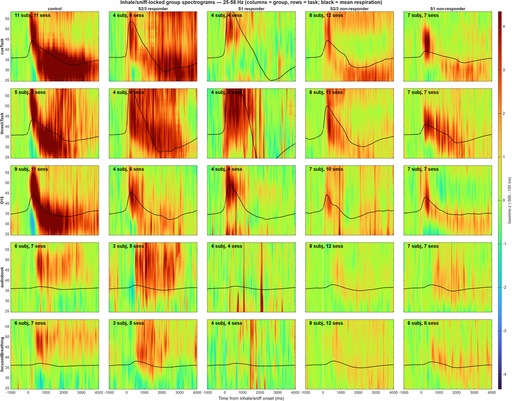

**Low band (2–25 Hz):**

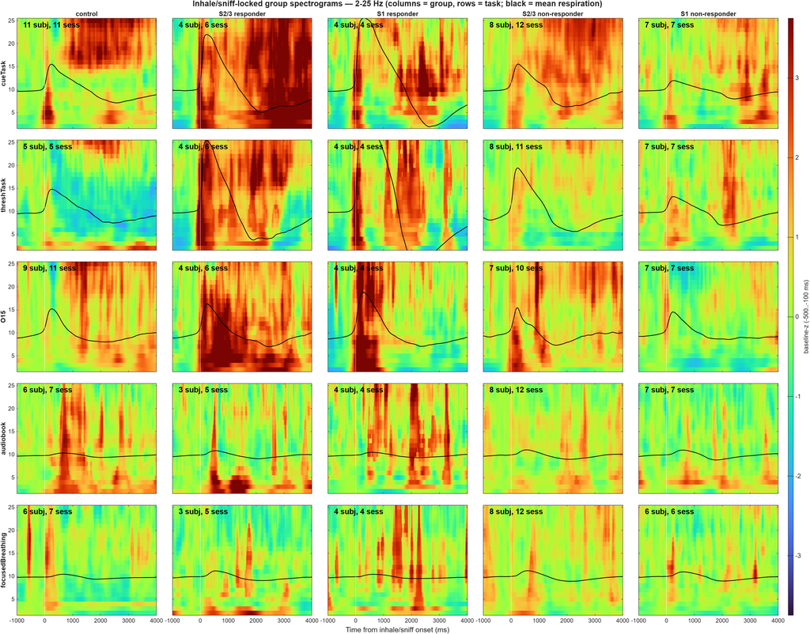

**High-gamma band (60–150 Hz):**

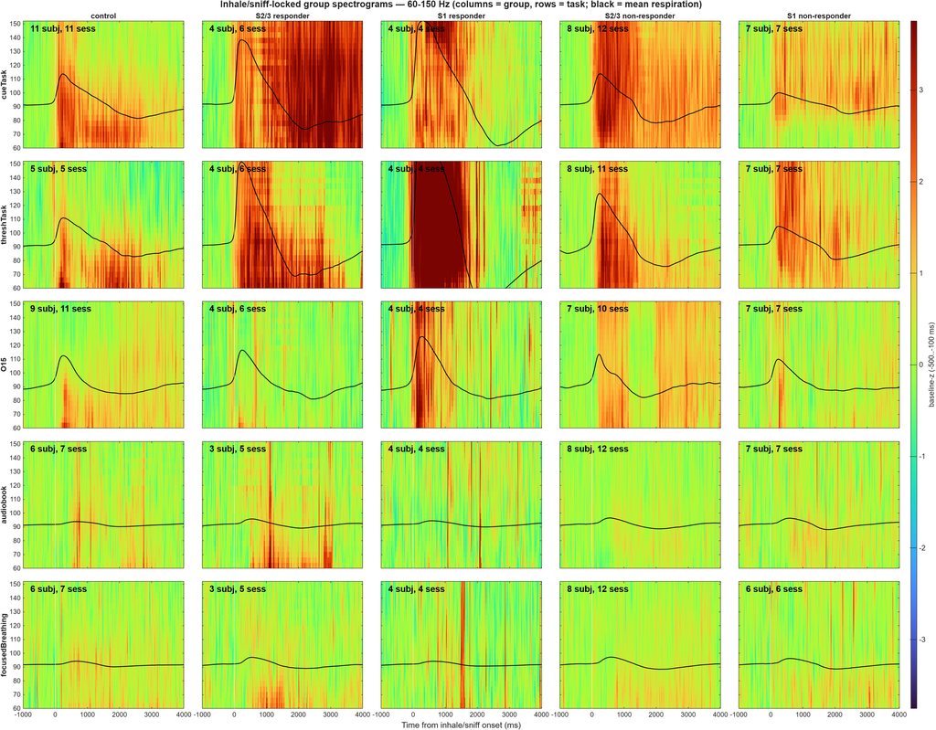

# 7 Per-breath gamma characterization

Each breath/sniff yields a large set of gamma descriptors (see Methods). Below is the **curated set of key metrics**, each plotted with **session 1/2/3/control on X**, colored by responder / non-responder / control, faceted by task; bars = session means ± SE. Every panel carries a one-line **description of how the measure is computed** (subtitle) and its **goodness statistics** (control↔︎Dupi and responder↔︎non-responder effect sizes) printed in the plot header.

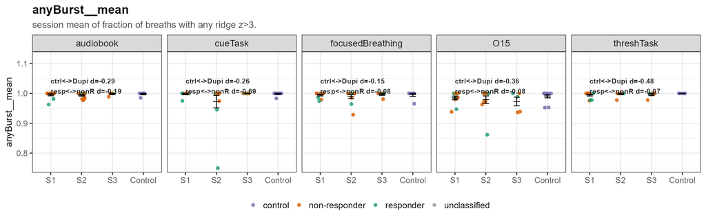

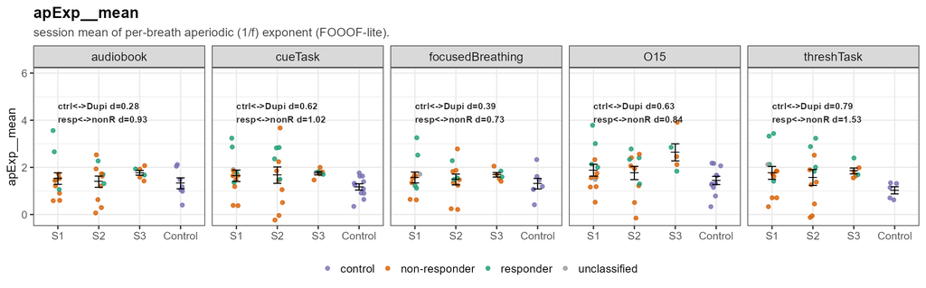

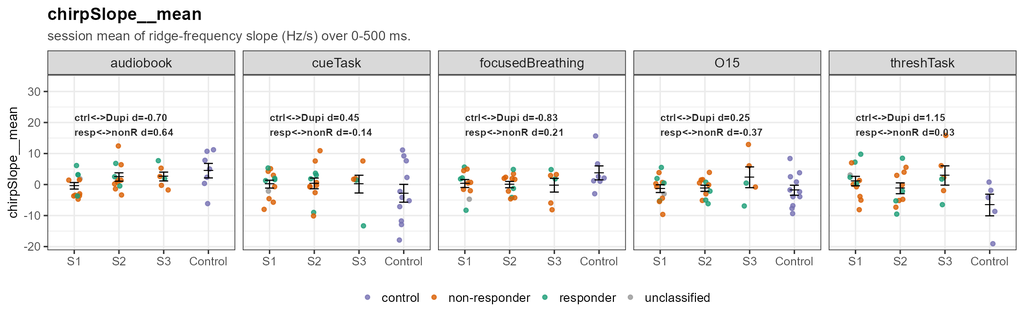

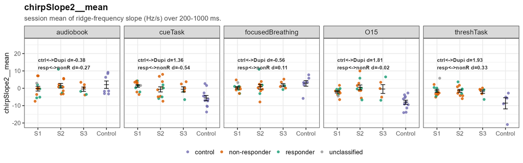

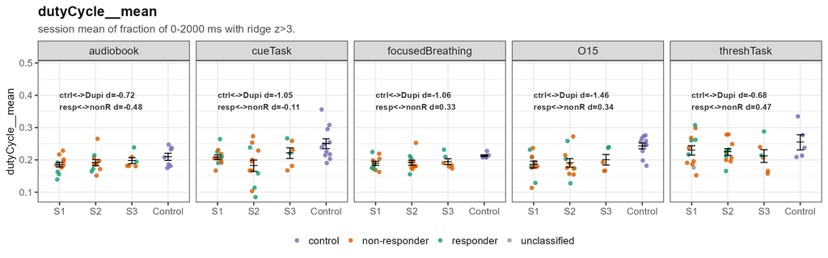

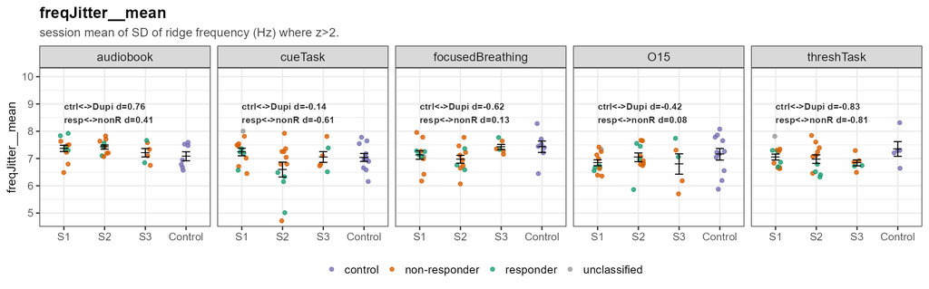

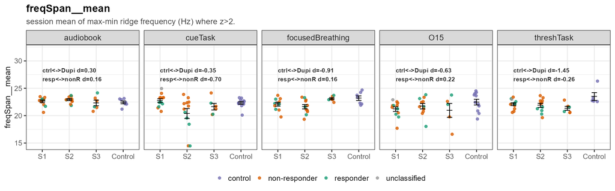

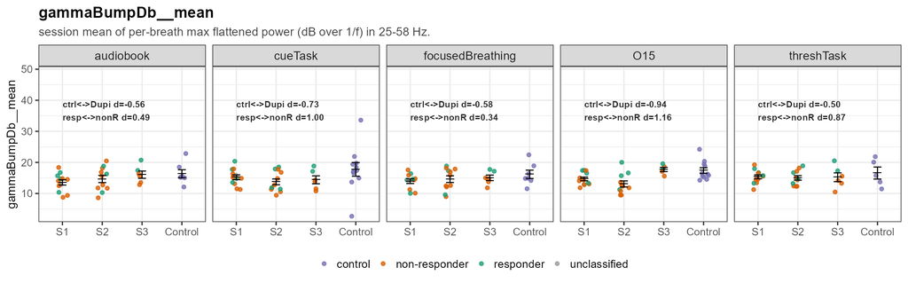

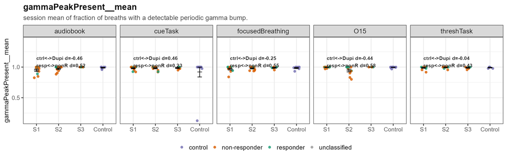

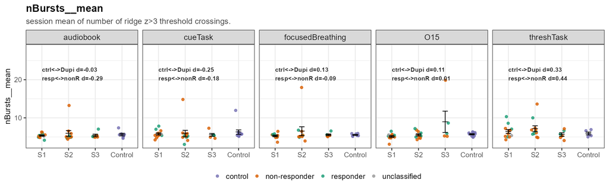

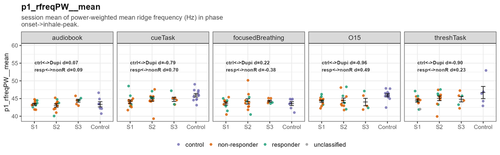

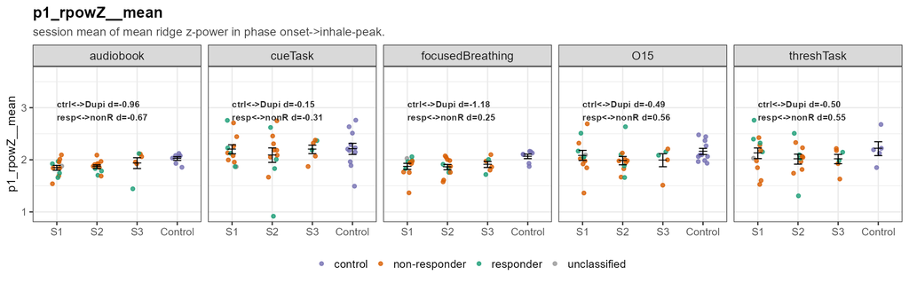

[10 more figures not shown]

# 8 Which measures are good? (low control variability + separation / tracking)

The headline question: measures with **low between-control variability** that also (1) separate control↔︎Dupi, (2) separate responder↔︎non-responder, and/or (3) track recovery across sessions. The table below ranks every measure by `goodness = |max separation effect| / (1 + |control CV|)`. This is the numeric **screen**; the corresponding plots for the full ranked set are in the next section, and each is annotated with its own goodness stats.

Top gamma measures (low control CV × high separation/tracking)

| task | metric | control_CV | sep_control_dupi | sep_resp_nonresp | recovery_rho_resp | goodness |
| --- | --- | --- | --- | --- | --- | --- |
| threshTask | w4_rfreqGated__mean | 0.053 | 1.52 | 0.39 | -0.44 | 1.44 |
| cueTask | w4_rfreqPW__mean | 0.071 | 1.52 | -0.15 | -0.54 | 1.42 |
| threshTask | w4_rfreqPW__mean | 0.056 | 1.46 | 0.30 | -0.49 | 1.38 |
| O15 | maxBurstMs__mean | 0.098 | -1.51 | 0.01 | 0.36 | 1.38 |
| cueTask | w4_rfreqGated__mean | 0.075 | 1.48 | -0.07 | -0.51 | 1.38 |
| threshTask | freqSpan__mean | 0.068 | -1.45 | -0.26 | -0.76 | 1.36 |
| O15 | timeAboveMs_base__mean | 0.056 | -1.41 | 0.60 | 0.03 | 1.33 |
| threshTask | peakFreq__mean | 0.053 | 1.40 | 0.17 | -0.58 | 1.33 |
| O15 | dutyCycle__mean | 0.123 | -1.46 | 0.34 | 0.39 | 1.30 |
| O15 | timeAboveMs__mean | 0.123 | -1.46 | 0.34 | 0.39 | 1.30 |
| O15 | w4_rfreqPW__mean | 0.033 | 1.32 | 0.00 | -0.42 | 1.28 |
| cueTask | w4_rfreqRaw__mean | 0.070 | 1.35 | -0.25 | -0.54 | 1.27 |
| threshTask | w4_rfreqRaw__mean | 0.056 | 1.32 | 0.30 | -0.49 | 1.25 |
| threshTask | w3_rfreqRaw__mean | 0.030 | 1.28 | 0.30 | -0.54 | 1.24 |
| threshTask | w3_rfreqPW__mean | 0.038 | 1.29 | 0.44 | -0.49 | 1.24 |
| threshTask | w3_rfreqGated__mean | 0.043 | 1.28 | 0.49 | -0.39 | 1.23 |
| O15 | w4_rfreqRaw__mean | 0.033 | 1.27 | 0.02 | -0.49 | 1.23 |
| O15 | chirpSlope2__mean | 0.483 | 1.81 | -0.02 | 0.16 | 1.22 |
| threshTask | w5_aucZ__mean | 0.067 | -1.30 | 0.02 | 0.54 | 1.22 |
| threshTask | w5_rpowZ__mean | 0.067 | -1.30 | 0.02 | 0.54 | 1.22 |
| threshTask | p3_rpowZ__mean | 0.091 | -1.30 | -0.13 | 0.47 | 1.19 |
| threshTask | apExp__mean | 0.332 | 0.79 | 1.53 | -0.27 | 1.15 |
| O15 | w4_rfreqGated__mean | 0.036 | 1.15 | -0.24 | -0.19 | 1.11 |
| focusedBreathing | p1_rpowZ__mean | 0.056 | -1.18 | 0.25 | -0.36 | 1.11 |
| threshTask | p2_rfreqPW__mean | 0.030 | 1.14 | 0.32 | -0.31 | 1.11 |
| cueTask | w5_rfreqPW__mean | 0.072 | 1.16 | -0.15 | -0.19 | 1.08 |
| threshTask | p2_rfreqRaw__mean | 0.026 | 1.09 | 0.22 | -0.49 | 1.06 |
| O15 | p3_rfreqPW__mean | 0.047 | 1.10 | -0.02 | -0.21 | 1.05 |
| threshTask | chirpSlope2__mean | 0.827 | 1.93 | 0.33 | -0.25 | 1.05 |
| O15 | w3_rfreqPW__mean | 0.048 | 1.10 | 0.54 | -0.18 | 1.05 |

# 9 Full ranked metric gallery

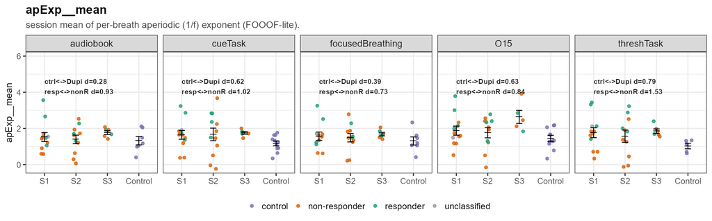

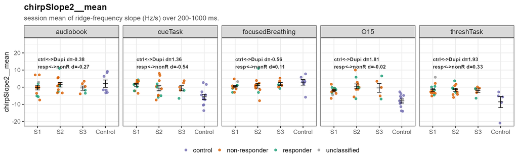

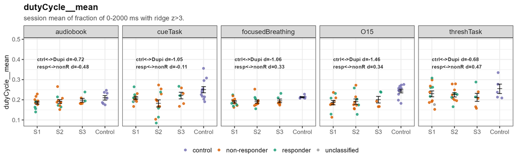

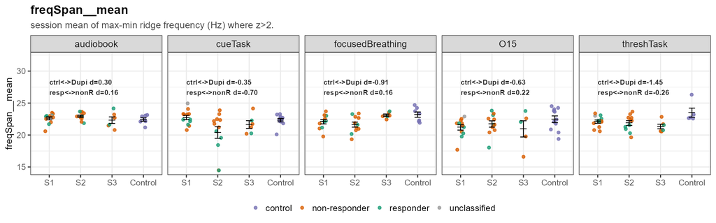

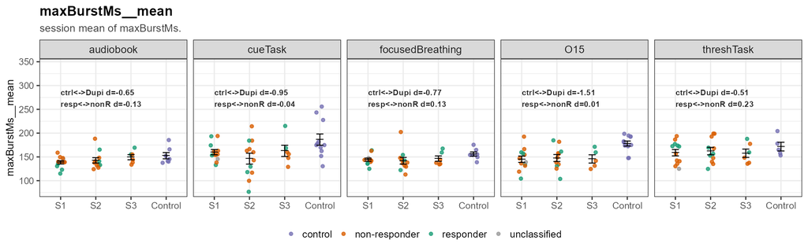

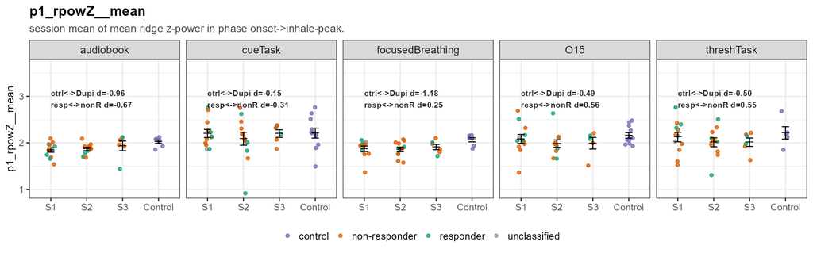

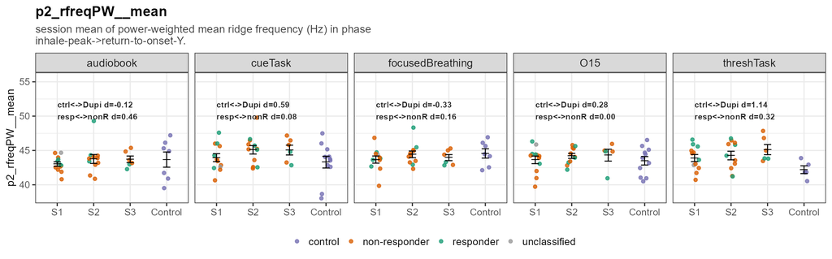

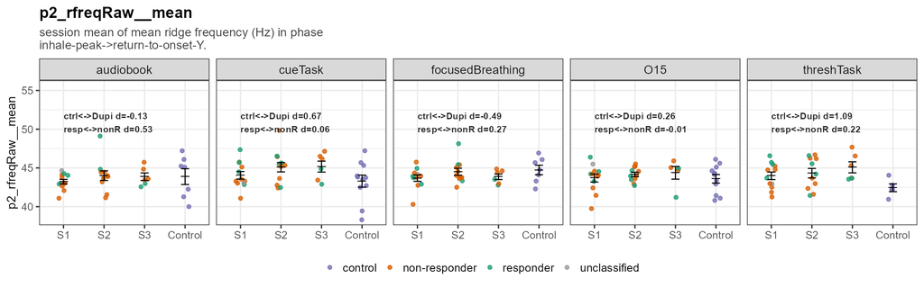

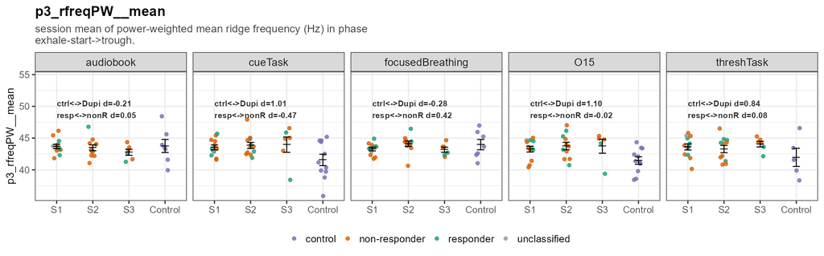

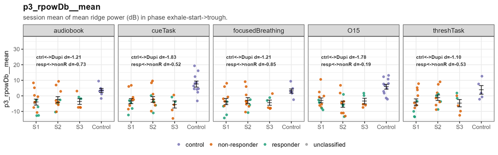

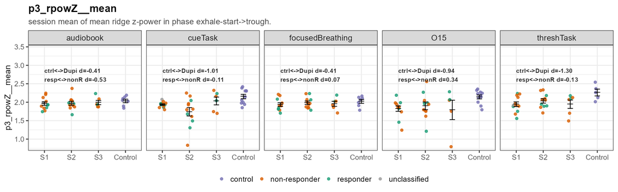

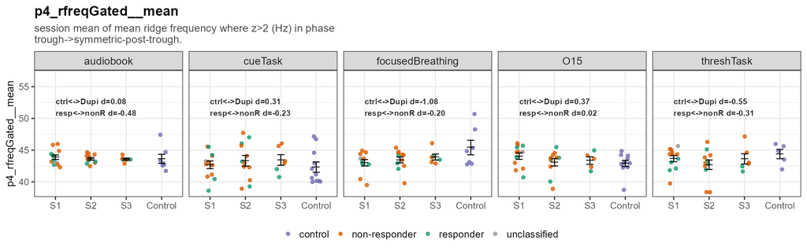

[16 more figures not shown]

# 10 Breathing tasks: a gamma-bursting deficit and a chirp-slope recovery

The two breathing blocks — **audiobook** (passive listening) and **focusedBreathing** — let us ask the headline question directly for a within-task, ecologically simple context: which per-breath measures both **separate Dupi from control** *and* **track across sessions**? Sweeping all 186 measures paired against each criterion, **nothing clears FDR on session tracking**, and only the focused-breathing bursting deficit clears FDR on separation. But two effects are direction-consistent and mechanistically coherent enough to flag as genuine leads — and they **dissociate by task**.

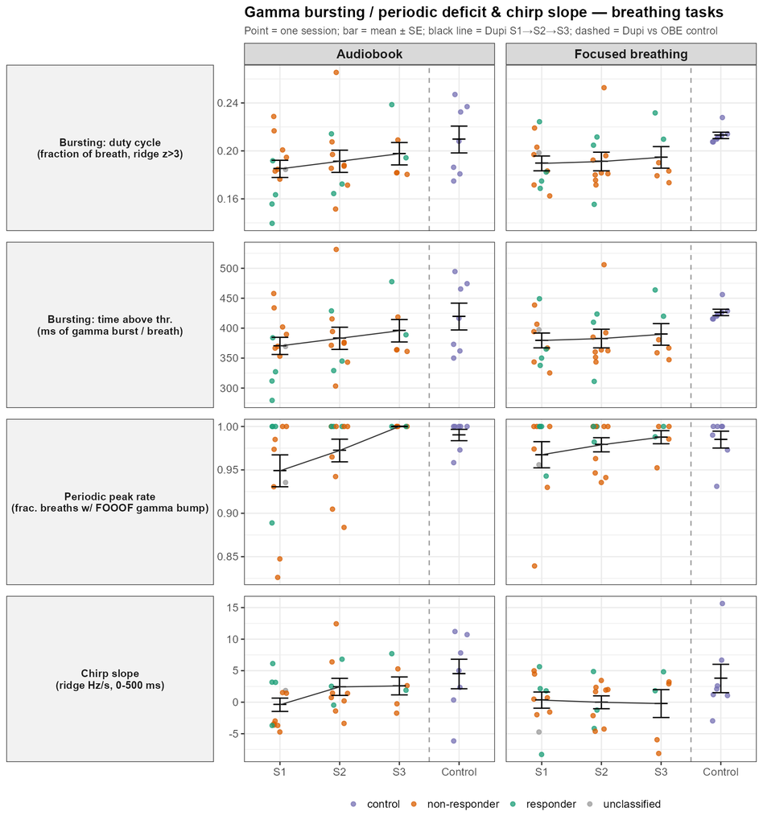

Highlighted breathing measures: control (mean±SD), Dupi session means, separation (d_sep, FDR), tracking (Spearman ρ), control/Dupi SD ratio; for chirp, the S1→S2 and S2→S3 step.

| task | metric | ctrl | S1 | S2 | S3 | d_sep | p_sep | p_sep_fdr | rho | p_rho | SDratio_ctrl_dupi | chirp_S1toS2 | chirp_S2toS3 |
| --- | --- | --- | --- | --- | --- | --- | --- | --- | --- | --- | --- | --- | --- |
| audiobook | timeAboveMs__mean | 419±59 | 370.000 | 383.0000 | 396.000 | -0.86 | 0.13000 | 0.390 | 0.12 | 0.530 | 1.12 | NA | NA |
| audiobook | dutyCycle__mean | 0.21±0.03 | 0.185 | 0.1910 | 0.198 | -0.86 | 0.13000 | 0.390 | 0.12 | 0.530 | 1.12 | NA | NA |
| audiobook | chirpSlope__mean | 4.47±6.2 | -0.408 | 2.4300 | 2.580 | -0.78 | 0.22000 | 0.520 | 0.33 | 0.085 | 1.52 | 2.84 | 0.15 |
| audiobook | gammaPeakPresent__mean | 0.99±0.017 | 0.949 | 0.9720 | 1.000 | -0.70 | 0.08200 | 0.360 | 0.42 | 0.022 | 0.34 | NA | NA |
| focusedBreathing | timeAboveMs__mean | 426±14 | 380.000 | 383.0000 | 390.000 | -1.71 | 0.00031 | 0.029 | 0.06 | 0.750 | 0.32 | NA | NA |
| focusedBreathing | dutyCycle__mean | 0.213±0.007 | 0.190 | 0.1910 | 0.195 | -1.71 | 0.00031 | 0.029 | 0.06 | 0.750 | 0.32 | NA | NA |
| focusedBreathing | chirpSlope__mean | 3.76±6 | 0.331 | -0.0151 | -0.218 | -0.93 | 0.12000 | 0.370 | -0.01 | 0.980 | 1.47 | -0.35 | -0.20 |
| focusedBreathing | gammaPeakPresent__mean | 0.985±0.026 | 0.967 | 0.9790 | 0.988 | -0.32 | 0.47000 | 0.740 | 0.10 | 0.630 | 0.71 | NA | NA |

**A gamma-bursting deficit (Dupi < control).** Duty cycle and time-above-threshold (fraction / ms of each breath the ridge spends at z > 3) are **lower in Dupi than control in both tasks**. It is statistically cleanest in focused breathing (d ≈ −1.7, FDR q = 0.029) — but that large effect size is **amplified by unusually tight control grouping**: the control SD is only ≈ ⅓ of the Dupi session SD (SD ratio 0.32). The audiobook deficit is more modest (d ≈ −0.9) but **variance-fair** (SD ratio ≈ 1.1). Because these are z-/threshold-based (not raw dB power), they are relatively robust to the 1/f confound. The deficit is **static** — it does not track across sessions (ρ ≈ 0.06–0.12). Read: a real, direction-consistent reduction in gamma bursting in Dupi, though individual sessions overlap and the focused-breathing effect size is partly a low-control-variance effect.

**A chirp-slope recovery, in audiobook, concentrated S1→S2.** Ridge-frequency slope (0–500 ms) sits near flat in Dupi at S1 and **climbs toward the control value across sessions in audiobook** — and essentially all of the movement is **S1→S2** (Δ ≈ +2.8 Hz/s), plateauing S2→S3 (Δ ≈ +0.15). Focused breathing shows no such recovery (it drifts the other way). This is the same ridge-sweep family that separated groups in the sniff tasks, so the direction is *a priori* motivated, but it is noisy (large SE) and does not survive FDR (ρ = 0.33, p ≈ 0.09).

**Periodic peak rate is ceiling-limited.** The fraction of breaths with a detectable periodic gamma bump rises toward control across sessions, but most Dupi are already **near ceiling at S1** (0.95–1.0), so the measure has little room to move and is hard to interpret as recovery.

**Net.** A **gamma-bursting deficit** (Dupi < control, clearest in focused breathing) and a **chirp-slope recovery** (audiobook, early S1→S2) are the two coherent breathing-task signals — a *separation* marker and a *tracking* marker that live in different tasks. Neither is confirmed (bursting doesn’t track; chirp doesn’t survive correction; S3 is n = 6), but both are direction-consistent and worth powering up.

# 11 Respiration–gamma coupling

Session-level coupling of gamma amplitude to respiratory phase: Tort modulation index (MI), preferred-phase resultant length, and an inhale/exhale gamma ratio. Plotted by session/control, colored by responder status.

Coupling measures: control CV and separation effect sizes

| taskRow | metric | control_CV | sep_control_dupi | sep_resp_nonresp |
| --- | --- | --- | --- | --- |
| cueTask | coup_MI | 1.046 | 0.274 | -0.250 |
| cueTask | coup_resultantLen | 0.249 | -0.329 | -0.419 |
| cueTask | coup_inhExhRatio | 0.030 | 0.436 | 0.494 |
| O15 | coup_MI | 0.821 | 0.171 | -0.380 |
| O15 | coup_resultantLen | 0.245 | -0.801 | -0.425 |
| O15 | coup_inhExhRatio | 0.032 | 1.294 | 0.417 |
| audiobook | coup_MI | 0.590 | 0.265 | 0.175 |
| audiobook | coup_resultantLen | 0.450 | 0.158 | -0.433 |
| audiobook | coup_inhExhRatio | 0.036 | -0.014 | -0.551 |
| focusedBreathing | coup_MI | 0.590 | 0.286 | 0.143 |
| focusedBreathing | coup_resultantLen | 0.450 | 0.115 | -0.373 |
| focusedBreathing | coup_inhExhRatio | 0.036 | -0.030 | -0.525 |
| threshTask | coup_MI | 1.835 | -0.252 | -0.014 |
| threshTask | coup_resultantLen | 0.440 | -0.341 | 0.314 |
| threshTask | coup_inhExhRatio | 0.014 | 0.473 | 0.672 |

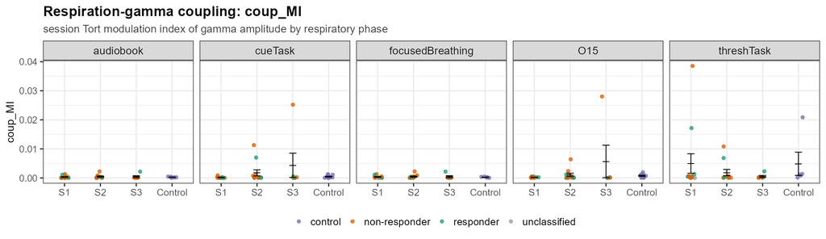

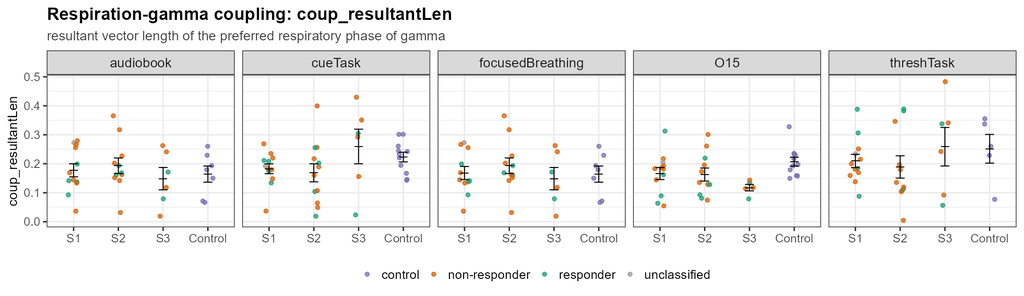

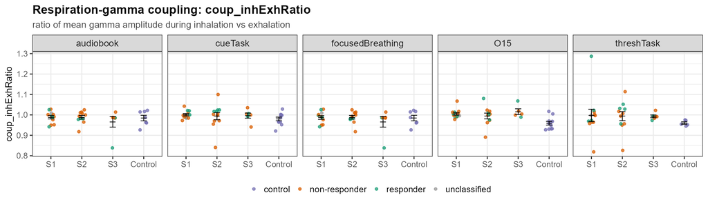

# 12 Robustness & confounds